[figure not shown]

[figure not shown]

[figure not shown]

# Data Description

The data we have chosen for this project is the Australian Road Deaths Database (ARDD) provided by the Australian Bureau of Infrastructure and Transport Research Economics (BITRE). The records are updated monthly from 1986 to 2021. Here is the link to the database : https://data.gov.au/dataset/ds-dga-5b530fb8-526e-4fbf-b0f6-aa24e84e4277/details.

There are two data files. The fatality data contains the demographic and details of people who have died within 30 days of the traffic accident due to injuries caused by an Australia road crash. The fatal crashes data contains the records for the crash, including information like the road type, and speed limit. The two data files can be connected by the crash ID. See Appendix for more detailed descriptions of each variable.

# Research Questions:

Q1: What demographic has a higher rate of traffic accidents?

Q2: Ranking of vehicle types by number of accidents

Q3: How does the car accident fatality link with the district and accident type?

Q4: Is there any correlation between accidents and holiday? And why are some explanations for the relation(s) or lack thereof.

Q5 :Has accident rate decreased or increased within the past decade (2010- 2020)?

Q6: Possible correlations between number of fatalities and speed limit zone

```
  Crash.ID State Month Year Crash.Type Number.Fatalities Bus.Involvement
1 20202001   Vic    12 2020   Multiple                 1              No
2 20204057    SA    12 2020     Single                 1              No
3 20203145   Qld    12 2020     Single                 1              No
4 20203208   Qld    12 2020     Single                 1              No
5 20203117   Qld    12 2020   Multiple                 2              No
6 20201199   NSW    12 2020     Single                 1              No
  Heavy.Rigid.Truck.Involvement Articulated.Truck.Involvement Speed.Limit
1                            No                           Yes         100
2                            No                            No         100
3                            No                            No          60
4                            No                            No         100
5                            No                           Yes         100
6                            No                            No          50
  National.LGA.Name.2017 Christmas.Period Easter.Period Time.of.day
1           Horsham (RC)              Yes            No       Night
2           Tatiara (DC)               No            No         Day
3     Sunshine Coast (R)               No            No       Night
4          Bundaberg (R)              Yes            No       Night
5          Cloncurry (S)              Yes            No         Day
6          Upper Lachlan               No            No         Day
```

```
  Crash.ID State Month Year Crash.Type Bus.Involvement
1 20203116   Qld    12 2020   Multiple              No
2 20201210   NSW    12 2020     Single              No
3 20203202   Qld    12 2020     Single              No
4 20201093   NSW    12 2020     Single              No
5 20203161   Qld    12 2020   Multiple              No
6 20203179   Qld    12 2020   Multiple              No
  Heavy.Rigid.Truck.Involvement Articulated.Truck.Involvement Speed.Limit
1                            No                            No          60
2                            No                            No         100
3                            No                            No         100
4                            No                            No         100
5                            No                            No          70
6                            No                            No         100
         Road.User Gender Age National.LGA.Name.2017 Christmas.Period
1 Motorcycle rider   Male  28             Cairns (R)               No
2        Passenger   Male  89                 Walcha              Yes
3           Driver   Male  21    Charters Towers (R)              Yes
4           Driver   Male  81                 Walcha               No
5           Driver Female  66        Moreton Bay (R)               No
6        Passenger   Male  79     Lockyer Valley (R)               No
  Easter.Period   Age.Group Time.of.day
1            No    26_to_39       Night
2            No 75_or_older         Day
3            No    17_to_25         Day
4            No 75_or_older       Night
5            No    65_to_74       Night
6            No 75_or_older         Day
```

# Data Analysis

# Question 3

#How does the car accident fatality link with the district and accident type?

First of all, we group the data by state and the type of car which have involved in the fatal accidents.

| State | Bus_Involved |
| --- | --- |
| ACT | 4 |
| NSW | 75 |
| NT | 6 |
| Qld | 43 |
| SA | 13 |
| Tas | 7 |
| Vic | 42 |
| WA | 19 |

```
# A tibble: 6 x 2
# Groups:   State [6]
  State Bus_Involved
  <chr>        <int>
1 ACT              4
2 NSW             75
3 NT               6
4 Qld             43
5 SA              13
6 Tas              7
```

```
# A tibble: 6 x 2
# Groups:   State [6]
  State Heavytruck_Involved
  <chr>               <int>
1 ACT                     3
2 NSW                   266
3 NT                      5
4 Qld                   144
5 SA                     53
6 Tas                    27
```

```
# A tibble: 6 x 2
# Groups:   State [6]
  State Articulated_truck_Involved
  <chr>                      <int>
1 ACT                            6
2 NSW                          344
3 NT                            15
4 Qld                          278
5 SA                           104
6 Tas                           29
```

```
# A tibble: 6 x 3
# Groups:   State [2]
  State Type                       Count
  <chr> <chr>                      <int>
1 ACT   Bus_Involved                   4
2 ACT   Heavytruck_Involved            3
3 ACT   Articulated_truck_Involved     6
4 NSW   Bus_Involved                  75
5 NSW   Heavytruck_Involved          266
6 NSW   Articulated_truck_Involved   344
```

In this table, we have got the count of different type of fatal accidents happened group by different states. This data is in long format which will be easier for us to plot the bar chart for better visualization.

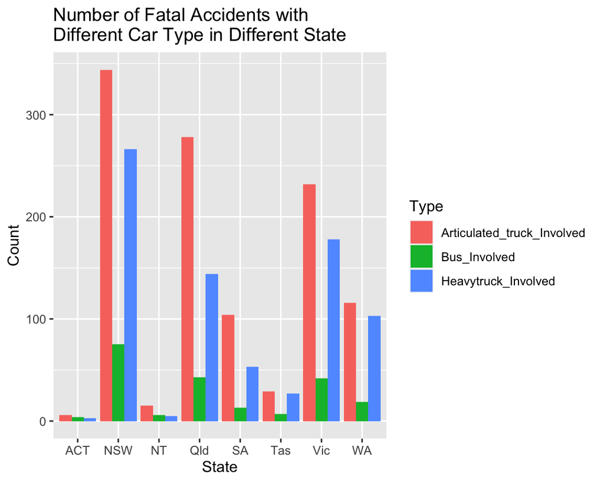

From the graph above: -NSW is the state with highest number of fatal accidents -follow by Qld and Vic.

Interpretation: Articulated truck is the heaviest among these 3 type of cars. Heavier car impose a greater impact on any accident which cause a higher fatalities.

Articulated truck is a vehicle which has a permanent or semi-permanent pivot joint in its construction. Only large vehicles need this structure which is easier for them to turn. But it also impose an additional risk for higher fatalities in an accident due to the complex mechanical structure.

Then, we group the data by states and the type of Road Users which have involved in the fatal accidents.

```
# A tibble: 6 x 3
# Groups:   State, Road.User [6]
  State Road.User                    Count
  <chr> <chr>                        <int>
1 ACT   Driver                          47
2 ACT   Motorcycle pillion passenger     1
3 ACT   Motorcycle rider                24
4 ACT   Passenger                       16
5 ACT   Pedal cyclist                    7
6 ACT   Pedestrian                      11
```

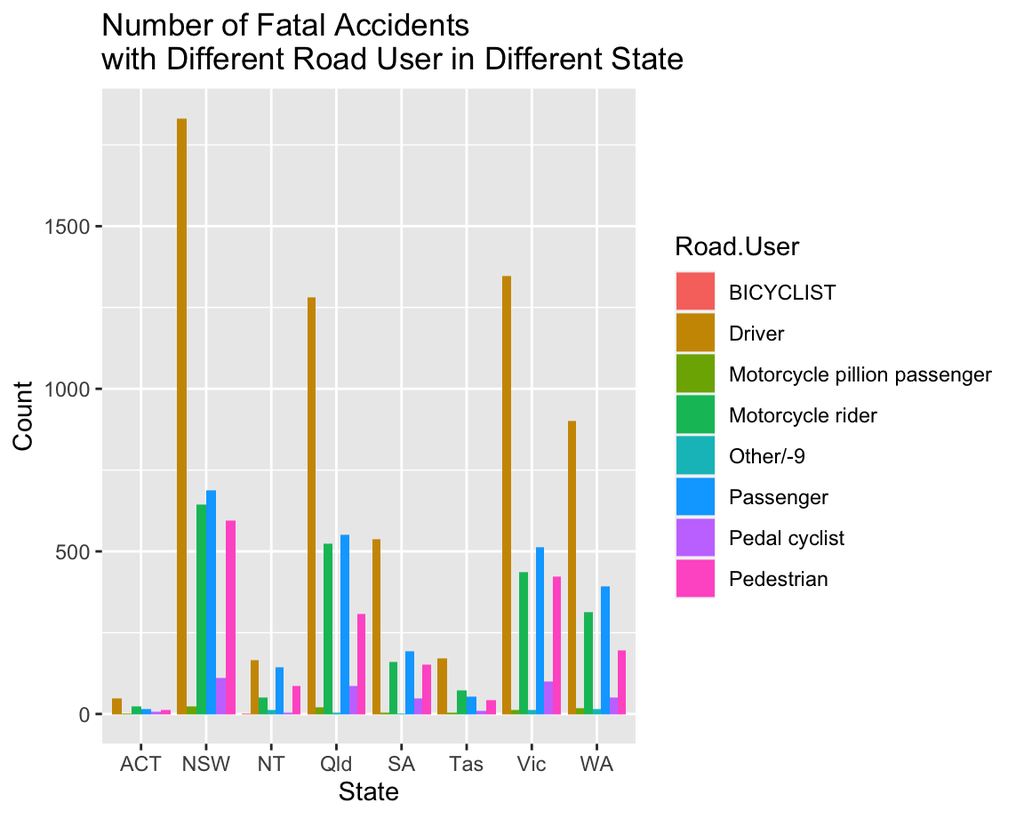

From the graph above:

Interpretation: Most fatal accidents with the drivers and passengers involved. relatively less pedestrian involved in fatal car accidents. We may interpret that most of the people drive in Australia, that is the reason more drivers and passenger involved in fatal car accidents. Another interpretation is most of the car accidents happened in highway or it is a crashed between cars or crashed between car and the road.

Then, we group the data by the crash type and count the number of it.

```
# A tibble: 6 x 3
# Groups:   State, Crash.Type [6]
  State Crash.Type Count
  <chr> <chr>      <int>
1 ACT   Multiple      57
2 ACT   Single        49
3 NSW   Multiple    1783
4 NSW   Single      2112
5 NT    Multiple     129
6 NT    Single       333
```

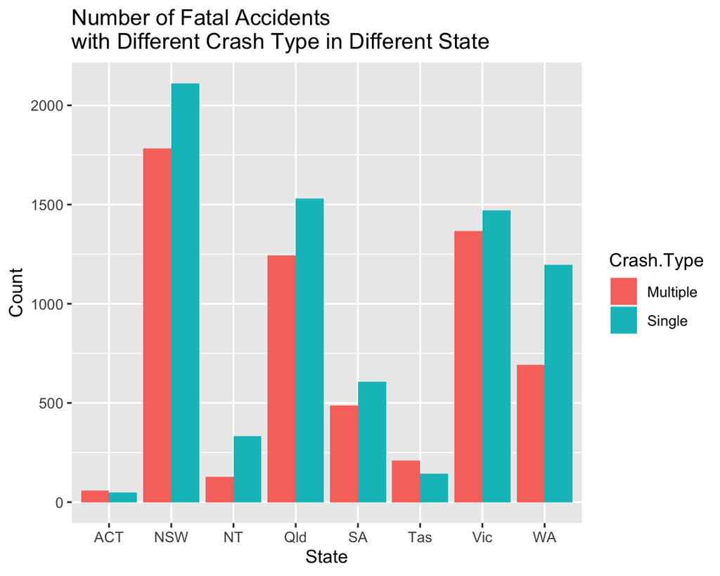

From the graph above:

In all the states except ACT and Tas: -all of the states have more single car crash than multiple car crash in terms of fatal car crashes.

How does the car accident fatality link with the district?

```
# A tibble: 6 x 3
# Groups:   State, National.LGA.Name.2017 [6]
  State National.LGA.Name.2017     n
  <chr> <chr>                  <int>
1 Qld   <NA>                    1786
2 NSW   <NA>                    1778
3 Vic   <NA>                    1638
4 WA    <NA>                     954
5 SA    <NA>                     415
6 NT    <NA>                     220
```

```
# A tibble: 6 x 3
# Groups:   State, National.LGA.Name.2017 [6]
  State National.LGA.Name.2017     n
  <chr> <chr>                  <int>
1 Qld   Brisbane (C)              87
2 NSW   Central Coast             82
3 Qld   Gold Coast (C)            68
4 Qld   Moreton Bay (R)           62
5 NSW   Lake Macquarie            56
6 NSW   Shoalhaven                55
```

From the table above: -first table contain value with NA -in this table, we don’t have detail district information for some cases. -However, in general, we could see that QLD, NSW, and Vic, these 3 states are top 3 in terms of number of fatal accidents. ##-***Be aware, this count do not reflect the actual ranking for the number of accidents.

-second table contain value without NA -in this table, we can conclude: +Brisbane in Qld is the district which has the most fatal car accidents happened, which has 87 cases within this 10 years. +Follow by Central Coast in NSW which is 82 fatal car accidents happened +The third one is Gold Coast which has 68 cases in this 10 years.

Interpretation: QLD, NSW, and Vic are the states that contain top 3 largest amount of population. Therefore, there will be higher chance of having a car accidents. It is the same as the district. Brisbane, Central Coast and Gold Coast are the districts with higher population which may leads to higher chance of an accident happened.